# Assignment for Reproducible Research

```r
library(ggplot2)
activity <- read.csv("./activity.csv",colClasses = c("integer","Date","integer"),na.strings = "NA")
```

## What is mean total number of steps taken per day?

- Calculate the total number of steps taken per day

```r
totals <- aggregate(steps ~ date,activity,sum)
```

- aggregated total steps per day

```r
head(totals)
```

```
##         date steps
## 1 2012-10-02   126
## 2 2012-10-03 11352
## 3 2012-10-04 12116
## 4 2012-10-05 13294
## 5 2012-10-06 15420
## 6 2012-10-07 11015
```

- Make a histogram of the total number of steps taken each day

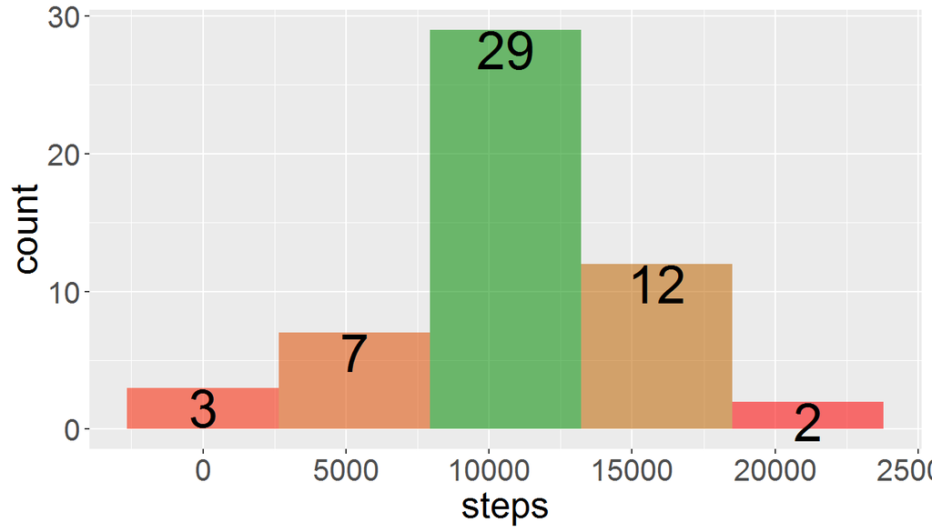

```r
g <- ggplot(totals,aes(x = totals$steps)) +
    labs(x="steps") +
    theme(plot.title = element_text(color="#666666", face="bold", size=32, hjust=0))

g + geom_histogram(aes(fill=..count..,label=..count..,alpha=0.1),bins=5)+
    stat_bin(aes(label=..count..),size=10, geom="text",vjust= +1,bins = 5)+
    scale_fill_gradient("Count", low = "red", high = "green4")+
    theme(legend.position="none",text = element_text(size=20))
```

- Calculate and report the mean and median of the total number of steps taken per day

```r
mean.activity <- format(mean(totals$steps),digits = 6)
median.activity <- median(totals$steps)
```

mean of total steps per day is 10766.2 median of total steps per day is 10765

## What is the average daily activity pattern?

```r
means <- aggregate(steps ~ interval,activity,mean)
```

- Make a time series plot (i.e. type = “l”) of the 5-minute interval (x-axis) and the average number of steps taken, averaged across all days (y-axis)

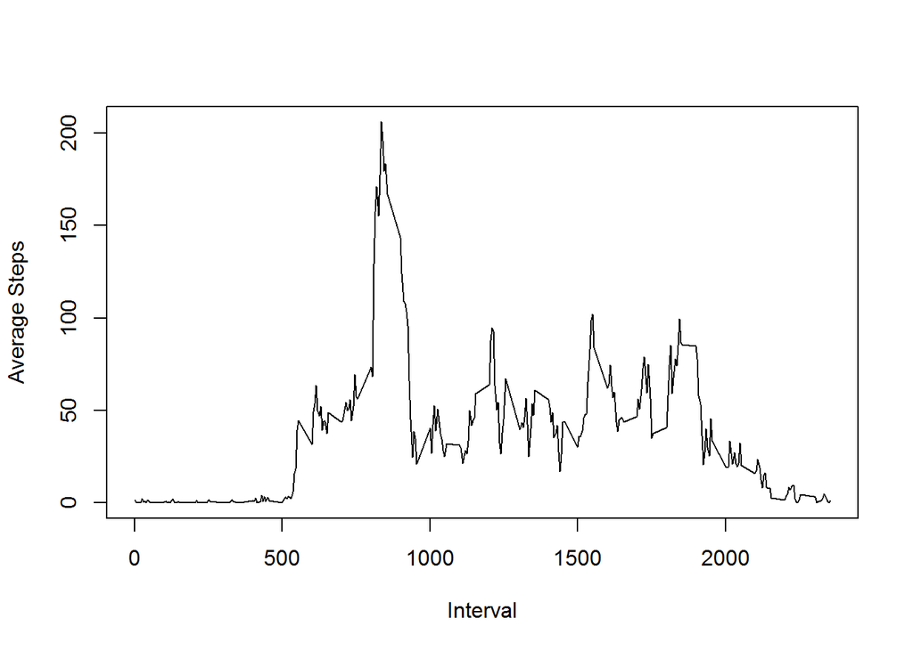

```r
plot(means$interval,means$steps,type = "l",xlab = "Interval",
     ylab = "Average Steps")
```

- Which 5-minute interval, on average across all the days in the dataset, contains the maximum number of steps?

```r
max <- means[which.max(means$steps),1]
```

Five min interval which contains max average number of steps is 835

## Imputing missing values

- Calculate and report the total number of missing values in the dataset (i.e. the total number of rows with NAs)

```r
rowcount <- sum(is.na(activity))
```

Rows w missing values is equal to 2304

```r
activity.imputed <- activity[is.na(activity$steps),]
merge <- merge(activity.imputed,means,by = "interval")
activity.imputed <- subset(merge,select = c("steps.y","date","interval"))
names(activity.imputed) <- names(activity)
activity.imputed <- rbind(activity[!(is.na(activity$steps)),],
                         activity.imputed)
activity.imputed <- activity.imputed[order(activity.imputed$date),]
activity.imputed$steps <- round(activity.imputed$steps,0)
head(activity.imputed,10)
```

```
##    steps       date interval
## 1      2 2012-10-01        0
## 10     0 2012-10-01        5
## 17     0 2012-10-01       10
## 29     0 2012-10-01       15
## 33     0 2012-10-01       20
## 45     2 2012-10-01       25
## 49     1 2012-10-01       30
## 58     1 2012-10-01       35
## 67     0 2012-10-01       40
## 73     1 2012-10-01       45
```

```r
totals.imputed <- aggregate(steps ~ date,activity.imputed,sum)
```

- Make a histogram of the total number of steps taken each day (w imputed)

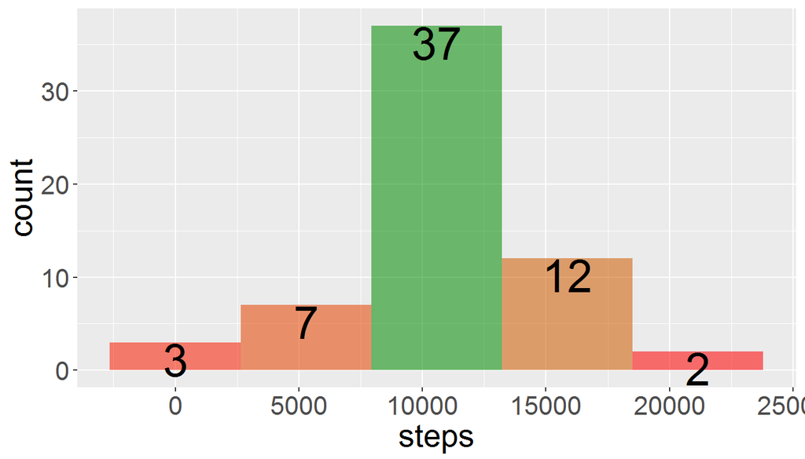

```r
g <- ggplot(totals.imputed,aes(x = totals.imputed$steps)) +
    labs(x="steps") +
    theme(plot.title = element_text(color="#666666", face="bold", size=32, hjust=0))

g + geom_histogram(aes(fill=..count..,label=..count..,alpha=0.1),bins=5)+
    stat_bin(aes(label=..count..),size=10, geom="text",vjust= +1,bins = 5)+
    scale_fill_gradient("Count", low = "red", high = "green4")+
    theme(legend.position="none",text = element_text(size=20))
```

- Calculate and report the mean and median of the total number of steps taken per day

```r
mean.imputed <- format(mean(totals.imputed$steps),digits = 6)
median.imputed <- format(median(totals.imputed$steps),digits=5)
```

mean of total steps per day is 10765.6 median of total steps per day is 10762

## Are there differences in activity patterns between weekdays and weekends?

- Create a new factor variable in the dataset with two levels - “weekday” and “weekend” indicating whether a given date is a weekday or weekend day.

```r
activity.imputed$Day <- as.factor(weekdays(activity.imputed$date))
activity.weekend <- activity.imputed [activity.imputed$Day %in%
                                          c("Saturday","Sunday"),]
activity.weekday <- activity.imputed [!activity.imputed$Day %in%
                                          c("Saturday","Sunday"),]
activity.weekday$Day <- "weekday"
activity.weekend$Day <- "weekend"

activity.imputed <- rbind(activity.weekend,activity.weekday)
activity.imputed <- activity.imputed[order(activity.imputed$date),]
activity.consolidated <- aggregate(steps~Day + interval,activity.imputed,mean)
```

- Make a panel plot containing a time series plot (i.e. type = “l”) of the 5-minute interval (x-axis) and the average number of steps taken

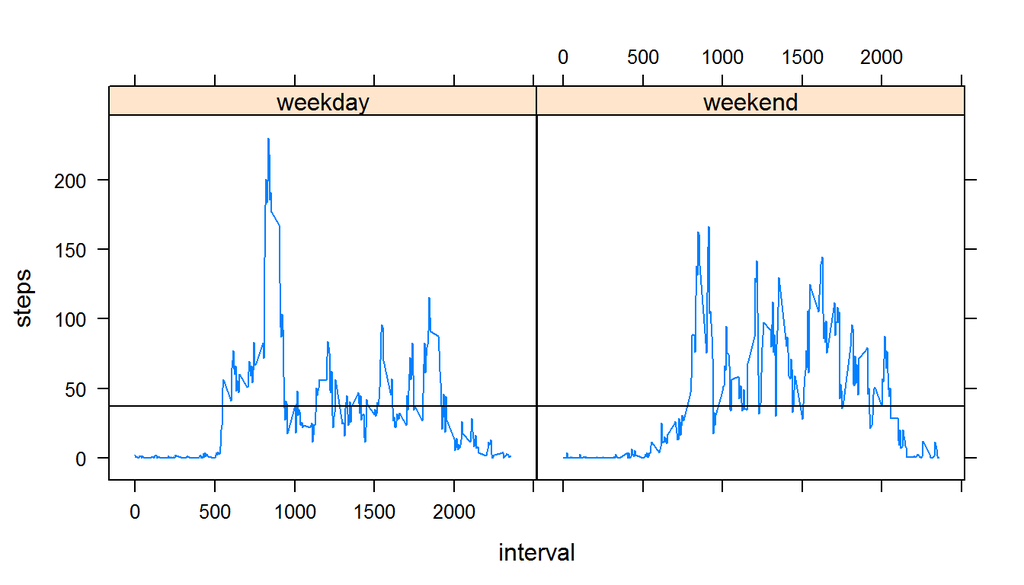

```r
library(lattice)
xyplot(steps~interval|Day,data =activity.consolidated,type = "l",
       panel = function(...){
            panel.xyplot(...)
            panel.abline(h=37.38)
       })
```